```python
import pandas as pd
import numpy as np
import matplotlib.pyplot as plt
from matplotlib.ticker import FuncFormatter
import seaborn as sns
```

# Introduction

## Data

The data comes from [here](https://divvy-tripdata.s3.amazonaws.com/index.html). It is 12 months of historical bike share data (January 2021 - December 2021).

## Goal

Convert casual riders to annual members in order to increase revenue.

## Task

Find the answer to the following: *How do annual members differ from casual riders?*

# Data Import and Clean-up

## Import CSVs

```python
jan2021 = pd.read_csv('divvy_monthlytripdata/202101-divvy-tripdata.csv')
feb2021 = pd.read_csv('divvy_monthlytripdata/202102-divvy-tripdata.csv')
mar2021 = pd.read_csv('divvy_monthlytripdata/202103-divvy-tripdata.csv')
apr2021 = pd.read_csv('divvy_monthlytripdata/202104-divvy-tripdata.csv')
may2021 = pd.read_csv('divvy_monthlytripdata/202105-divvy-tripdata.csv')
jun2021 = pd.read_csv('divvy_monthlytripdata/202106-divvy-tripdata.csv')
jul2021 = pd.read_csv('divvy_monthlytripdata/202107-divvy-tripdata.csv')
aug2021 = pd.read_csv('divvy_monthlytripdata/202108-divvy-tripdata.csv')
sep2021 = pd.read_csv('divvy_monthlytripdata/202109-divvy-tripdata.csv')
oct2021 = pd.read_csv('divvy_monthlytripdata/202110-divvy-tripdata.csv')
nov2021 = pd.read_csv('divvy_monthlytripdata/202111-divvy-tripdata.csv')
dec2021 = pd.read_csv('divvy_monthlytripdata/202112-divvy-tripdata.csv')
```

## Merge Tables

```python
entire_dataset = [jan2021, feb2021, mar2021, apr2021, may2021, jun2021, jul2021, aug2021, sep2021, oct2021, nov2021, dec2021]
df = pd.concat(entire_dataset, ignore_index = True)
#df.columns = df.columns.str.lower()#.str.replace(' ', '_')
df.info()
```

```
<class 'pandas.core.frame.DataFrame'>
RangeIndex: 5595063 entries, 0 to 5595062
Data columns (total 13 columns):
 #   Column              Dtype
---  ------              -----
 0   ride_id             object
 1   rideable_type       object
 2   started_at          object
 3   ended_at            object
 4   start_station_name  object
 5   start_station_id    object
 6   end_station_name    object
 7   end_station_id      object
 8   start_lat           float64
 9   start_lng           float64
 10  end_lat             float64
 11  end_lng             float64
 12  member_casual       object
dtypes: float64(4), object(9)
memory usage: 554.9+ MB
```

## Null Values

```python
df.isnull().sum()/(len(df))*100
```

```
ride_id                0.000000
rideable_type          0.000000
started_at             0.000000
ended_at               0.000000
start_station_name    12.346760
start_station_id      12.346706
end_station_name      13.211111
end_station_id        13.211111
start_lat              0.000000
start_lng              0.000000
end_lat                0.085272
end_lng                0.085272
member_casual          0.000000
dtype: float64
```

```python
proportion_null_rows = df.isnull().any(axis = 1).mean()
f'{round(proportion_null_rows*100, 2)}% of {df.shape[0]} rows contain null values'
```

```
'17.99% of 5595063 rows contain null values'
```

```python
df = df.dropna(axis = 0)
```

```python
proportion_null_rows = df.isnull().any(axis = 1).mean()
f'{round(proportion_null_rows*100, 2)}% of {df.shape[0]} rows contain null values'
```

```
'0.0% of 4588302 rows contain null values'
```

## Data Types

```python
df.dtypes
```

```
ride_id                object
rideable_type          object
started_at             object
ended_at               object
start_station_name     object
start_station_id       object
end_station_name       object
end_station_id         object
start_lat             float64
start_lng             float64
end_lat               float64
end_lng               float64
member_casual          object
dtype: object
```

```python
df['started_at'] = pd.to_datetime(df['started_at'], format = '%Y-%m-%d %H:%M:%S')
df['ended_at'] = pd.to_datetime(df['ended_at'], format = '%Y-%m-%d %H:%M:%S')
```

## Adding Features

```python
df['ride_length'] = df['ended_at'] - df['started_at']
df['day_of_week'] = df['started_at'].dt.day_name() #day_name() for name, dt.dayofweek for number
df['day_num'] = df['started_at'].dt.dayofweek + 1
days = ['Monday', 'Tuesday', 'Wednesday',
        'Thursday', 'Friday', 'Saturday',
        'Sunday']

df['month'] = df['started_at'].dt.month
months = ['Jan', 'Feb', 'Mar', 'Apr',
          'May', 'Jun', 'Jul', 'Aug',
          'Sep', 'Oct', 'Nov', 'Dec']

df['quarters'] = np.ceil(df['month'] / 3).astype(int)

df['start_hour'] = df['started_at'].dt.hour
df['ride_length_s'] = df['ride_length'].dt.total_seconds()
df['ride_length_m'] = round(df['ride_length_s']/60, 2)
```

```python
member = df[df['member_casual'] == 'member']
casual = df[df['member_casual'] == 'casual']
```

```python
trips_df = pd.DataFrame()

trips_df['total_trips'] = [df.shape[0]]
trips_df['total_trips_member'] = [member.shape[0]]
trips_df['total_trips_casual'] = [casual.shape[0]]
trips_df['member_pct'] = round((trips_df['total_trips_member'] / trips_df['total_trips']) * 100, 2)
trips_df['casual_pct'] = round((trips_df['total_trips_casual'] / trips_df['total_trips']) * 100, 2)
```

```python
top_start_stations = df['start_station_name'].value_counts().head(10).index
top_start_stations = sorted(top_start_stations, key=lambda x: df['start_station_name'].value_counts()[x])
top_end_stations = df['end_station_name'].value_counts().head(10).index
top_end_stations = sorted(top_end_stations, key=lambda x: df['end_station_name'].value_counts()[x])
top_stations = df[df['start_station_name'].isin(top_start_stations) & df['end_station_name'].isin(top_end_stations)]

filtered_members = df.dropna(subset=['start_station_name', 'end_station_name']).loc[df['member_casual'] == 'member']
top_start_stations_members = filtered_members['start_station_name'].value_counts().head(10)
top_end_stations_members = filtered_members['end_station_name'].value_counts().head(10)
top_stations_members = pd.concat([top_start_stations_members, top_end_stations_members], axis=1, keys=['Start', 'End']).reset_index()
top_stations_members = top_stations_members.melt(id_vars='index', var_name='Type', value_name='Number of Rides')

filtered_casual = df.dropna(subset=['start_station_name', 'end_station_name']).loc[df['member_casual'] == 'casual']
top_start_stations_casual = filtered_casual['start_station_name'].value_counts().head(10)
top_end_stations_casual = filtered_casual['end_station_name'].value_counts().head(10)
top_stations_casual = pd.concat([top_start_stations_casual, top_end_stations_casual], axis=1, keys=['Start', 'End']).reset_index()
top_stations_casual = top_stations_casual.melt(id_vars='index', var_name='Type', value_name='Number of Rides')
```

```python
ride_counts_month = df.groupby(['month', 'member_casual']).size().reset_index(name = 'ride_count')
ride_counts_hour = df.groupby(['start_hour', 'member_casual']).size().reset_index(name = 'ride_count')

peaks_casual = ride_counts_hour.loc[ride_counts_hour[ride_counts_hour['member_casual'] == 'casual']['ride_count'].idxmax()]['start_hour']
peaks_member = ride_counts_hour.loc[ride_counts_hour[ride_counts_hour['member_casual'] == 'member']['ride_count'].idxmax()]['start_hour']
```

```python
mask = df['ride_length'] >= pd.Timedelta(seconds = 0)
df = df[mask]
df.head()
```

|  | ride_id | rideable_type | started_at | ended_at | start_station_name | start_station_id | end_station_name | end_station_id | start_lat | start_lng | ... | end_lng | member_casual | ride_length | day_of_week | day_num | month | quarters | start_hour | ride_length_s | ride_length_m |
| --- | --- | --- | --- | --- | --- | --- | --- | --- | --- | --- | --- | --- | --- | --- | --- | --- | --- | --- | --- | --- | --- |
| 9 | B9F73448DFBE0D45 | classic_bike | 2021-01-24 19:15:38 | 2021-01-24 19:22:51 | California Ave & Cortez St | 17660 | Wood St & Augusta Blvd | 657 | 41.900363 | -87.696704 | ... | -87.672200 | member | 0 days 00:07:13 | Sunday | 7 | 1 | 1 | 19 | 433.0 | 7.22 |
| 10 | 457C7F4B5D3DA135 | electric_bike | 2021-01-23 12:57:38 | 2021-01-23 13:02:10 | California Ave & Cortez St | 17660 | California Ave & North Ave | 13258 | 41.900406 | -87.696733 | ... | -87.696890 | member | 0 days 00:04:32 | Saturday | 6 | 1 | 1 | 12 | 272.0 | 4.53 |
| 11 | 57C750326F9FDABE | electric_bike | 2021-01-09 15:28:04 | 2021-01-09 15:37:51 | California Ave & Cortez St | 17660 | Wood St & Augusta Blvd | 657 | 41.900374 | -87.696688 | ... | -87.672178 | casual | 0 days 00:09:47 | Saturday | 6 | 1 | 1 | 15 | 587.0 | 9.78 |
| 12 | 4D518C65E338D070 | electric_bike | 2021-01-09 15:28:57 | 2021-01-09 15:37:54 | California Ave & Cortez St | 17660 | Wood St & Augusta Blvd | 657 | 41.900379 | -87.696716 | ... | -87.672177 | casual | 0 days 00:08:57 | Saturday | 6 | 1 | 1 | 15 | 537.0 | 8.95 |
| 13 | 9D08A3AFF410474D | classic_bike | 2021-01-24 15:56:59 | 2021-01-24 16:07:08 | California Ave & Cortez St | 17660 | Wood St & Augusta Blvd | 657 | 41.900363 | -87.696704 | ... | -87.672200 | casual | 0 days 00:10:09 | Sunday | 7 | 1 | 1 | 15 | 609.0 | 10.15 |

5 rows × 21 columns

```python
df.dtypes
```

```
ride_id                        object
rideable_type                  object
started_at             datetime64[ns]
ended_at               datetime64[ns]
start_station_name             object
start_station_id               object
end_station_name               object
end_station_id                 object
start_lat                     float64
start_lng                     float64
end_lat                       float64
end_lng                       float64
member_casual                  object
ride_length           timedelta64[ns]
day_of_week                    object
day_num                         int64
month                           int64
quarters                        int64
start_hour                      int64
ride_length_s                 float64
ride_length_m                 float64
dtype: object
```

## Duplicate Values

```python
df.nunique()
```

```
ride_id               4588186
rideable_type               3
started_at            3933221
ended_at              3925760
start_station_name        842
start_station_id          829
end_station_name          839
end_station_id            827
start_lat              348202
start_lng              329287
end_lat                395769
end_lng                359486
member_casual               2
ride_length             23594
day_of_week                 7
day_num                     7
month                      12
quarters                    4
start_hour                 24
ride_length_s           23594
ride_length_m           23594
dtype: int64
```

```python
df.describe().T
```

|  | count | mean | std | min | 25% | 50% | 75% | max |
| --- | --- | --- | --- | --- | --- | --- | --- | --- |
| start_lat | 4588186.0 | 41.903036 | 0.040345 | 41.648501 | 41.882242 | 41.89766 | 41.926277 | 42.064854 |
| start_lng | 4588186.0 | -87.643505 | 0.023317 | -87.83 | -87.655486 | -87.640552 | -87.627691 | -87.528232 |
| end_lat | 4588186.0 | 41.90333 | 0.040491 | 41.648501 | 41.882479 | 41.898203 | 41.926756 | 42.168116 |
| end_lng | 4588186.0 | -87.643744 | 0.023527 | -87.83 | -87.655976 | -87.640981 | -87.627691 | -87.524517 |
| ride_length | 4588186 | 0 days 00:21:48.692097704 | 0 days 03:04:25.636762104 | 0 days 00:00:00 | 0 days 00:06:57 | 0 days 00:12:12 | 0 days 00:22:07 | 38 days 20:24:09 |
| day_num | 4588186.0 | 4.196892 | 2.003728 | 1.0 | 2.0 | 4.0 | 6.0 | 7.0 |
| month | 4588186.0 | 7.285887 | 2.472889 | 1.0 | 6.0 | 7.0 | 9.0 | 12.0 |
| quarters | 4588186.0 | 2.757606 | 0.85159 | 1.0 | 2.0 | 3.0 | 3.0 | 4.0 |
| start_hour | 4588186.0 | 14.248928 | 5.00021 | 0.0 | 11.0 | 15.0 | 18.0 | 23.0 |
| ride_length_s | 4588186.0 | 1308.692098 | 11065.636762 | 0.0 | 417.0 | 732.0 | 1327.0 | 3356649.0 |
| ride_length_m | 4588186.0 | 21.811533 | 184.427279 | 0.0 | 6.95 | 12.2 | 22.12 | 55944.15 |

# Analysis

```python
member_color = '#49538d'
casual_color = '#94a1ca'
```

## General

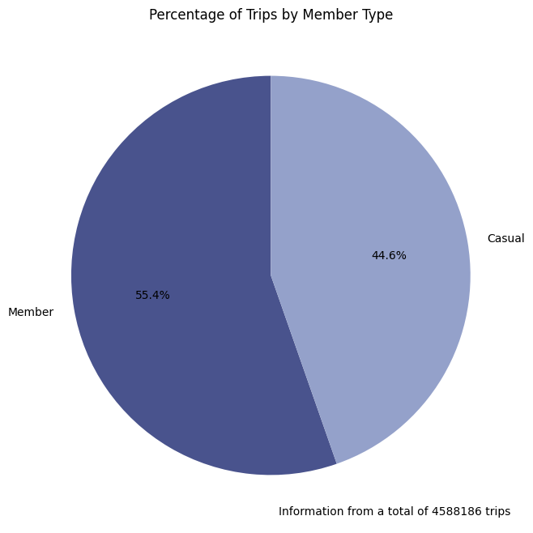

```python
labels = ['Member', 'Casual']
sizes = [trips_df['member_pct'].values[0], trips_df['casual_pct'].values[0]]
colors = [member_color, casual_color]

plt.figure(figsize = (8, 8))
plt.pie(sizes,
        labels = labels,
        autopct = '%1.1f%%',
        colors = colors,
        startangle = 90)
plt.title('Percentage of Trips by Member Type')

total_trips = 45881
bottom_message = f"Information from a total of {df.shape[0]} trips"
plt.text(0.98, 0.02, bottom_message, fontsize = 10, color = 'black',
         ha = 'right', transform = plt.gca().transAxes)

plt.show()
```

## Rideable Type

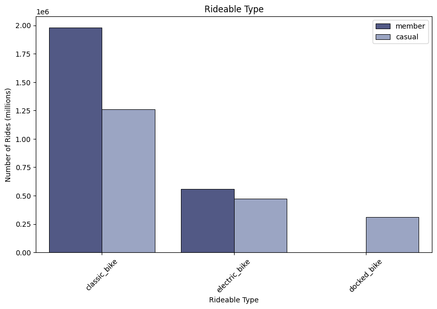

```python
plt.figure(figsize = (10, 6))
sns.countplot(x = 'rideable_type',
              hue= 'member_casual',
              data = df,
              palette = {'member': member_color, 'casual': casual_color},
              order = df['rideable_type'].value_counts().index,
              linewidth = 0.7,
              edgecolor = 'black')
plt.title('Rideable Type')
plt.xlabel('Rideable Type')
plt.ylabel('Number of Rides (millions)')
plt.xticks(rotation = 45)
plt.legend()
plt.show()
```

## Start Hour

```python
df.head()
```

|  | ride_id | rideable_type | started_at | ended_at | start_station_name | start_station_id | end_station_name | end_station_id | start_lat | start_lng | ... | end_lng | member_casual | ride_length | day_of_week | day_num | month | quarters | start_hour | ride_length_s | ride_length_m |
| --- | --- | --- | --- | --- | --- | --- | --- | --- | --- | --- | --- | --- | --- | --- | --- | --- | --- | --- | --- | --- | --- |
| 9 | B9F73448DFBE0D45 | classic_bike | 2021-01-24 19:15:38 | 2021-01-24 19:22:51 | California Ave & Cortez St | 17660 | Wood St & Augusta Blvd | 657 | 41.900363 | -87.696704 | ... | -87.672200 | member | 0 days 00:07:13 | Sunday | 7 | 1 | 1 | 19 | 433.0 | 7.22 |
| 10 | 457C7F4B5D3DA135 | electric_bike | 2021-01-23 12:57:38 | 2021-01-23 13:02:10 | California Ave & Cortez St | 17660 | California Ave & North Ave | 13258 | 41.900406 | -87.696733 | ... | -87.696890 | member | 0 days 00:04:32 | Saturday | 6 | 1 | 1 | 12 | 272.0 | 4.53 |
| 11 | 57C750326F9FDABE | electric_bike | 2021-01-09 15:28:04 | 2021-01-09 15:37:51 | California Ave & Cortez St | 17660 | Wood St & Augusta Blvd | 657 | 41.900374 | -87.696688 | ... | -87.672178 | casual | 0 days 00:09:47 | Saturday | 6 | 1 | 1 | 15 | 587.0 | 9.78 |
| 12 | 4D518C65E338D070 | electric_bike | 2021-01-09 15:28:57 | 2021-01-09 15:37:54 | California Ave & Cortez St | 17660 | Wood St & Augusta Blvd | 657 | 41.900379 | -87.696716 | ... | -87.672177 | casual | 0 days 00:08:57 | Saturday | 6 | 1 | 1 | 15 | 537.0 | 8.95 |
| 13 | 9D08A3AFF410474D | classic_bike | 2021-01-24 15:56:59 | 2021-01-24 16:07:08 | California Ave & Cortez St | 17660 | Wood St & Augusta Blvd | 657 | 41.900363 | -87.696704 | ... | -87.672200 | casual | 0 days 00:10:09 | Sunday | 7 | 1 | 1 | 15 | 609.0 | 10.15 |

5 rows × 21 columns

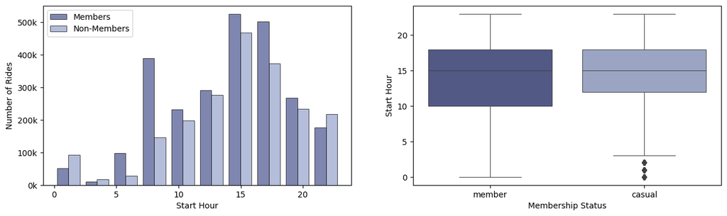

```python
plt.figure(figsize = (15, 4))
plt.subplot(1, 2, 1)
plt.hist([member['start_hour'],
          casual['start_hour']],
         color = [member_color, casual_color],
         label = ['Members', 'Non-Members'],
         alpha = 0.7,
         edgecolor = 'black',
         linewidth = 0.7)

plt.xlabel('Start Hour')
plt.ylabel('Number of Rides')
plt.legend()

plt.gca().yaxis.set_major_formatter(FuncFormatter(lambda x, _: '{:,.0f}k'.format(x/1000)))

plt.subplot(1, 2, 2)
sns.boxplot(x = 'member_casual', y = 'start_hour', data = df,
            palette = {'member': member_color, 'casual': casual_color},
            linewidth = 0.7)
plt.xlabel('Membership Status')
plt.ylabel('Start Hour')

plt.show()
```

```python
f"Peak Start Hour (Casual): {peaks_casual}:00.\
 Peak Start Hour (Member): {peaks_member}:00"
```

```
'Peak Start Hour (Casual): 17:00. Peak Start Hour (Member): 17:00'
```

[figure not shown]

```python
plt.figure(figsize = (10, 6))
sns.lineplot(x = 'start_hour', y = 'ride_count',
             hue = 'member_casual',
             data = ride_counts_hour,
             palette = [casual_color, member_color],
             linewidth = 3)
plt.xlabel('Start Hour')
plt.ylabel('Average Number of Rides')
plt.title('Average Ridership by Start Hour')

plt.gca().yaxis.set_major_formatter(FuncFormatter(lambda x, _: '{:,.0f}k'.format(x/1000)))

plt.show()
```

## Stations - General

Top Start Stations

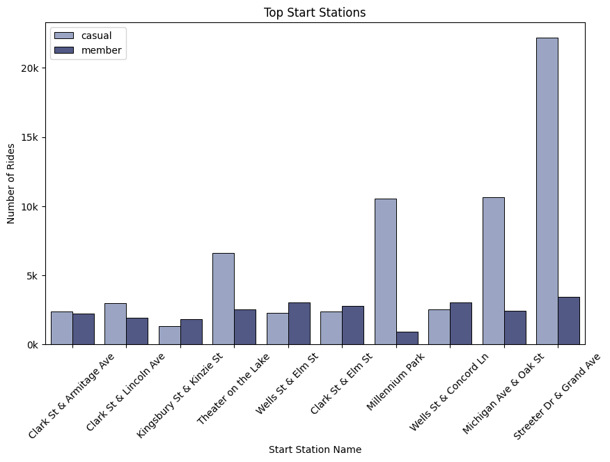

```python
plt.figure(figsize = (10, 6))
sns.countplot(x = 'start_station_name',
              hue = 'member_casual',
              data = top_stations,
              palette = {'member': member_color, 'casual': casual_color},
              order = top_start_stations,
              linewidth = 0.7,
              edgecolor = 'black')
plt.title('Top Start Stations')
plt.xlabel('Start Station Name')
plt.ylabel('Number of Rides')

plt.gca().yaxis.set_major_formatter(FuncFormatter(lambda x, _: '{:,.0f}k'.format(x/1000)))

plt.xticks(rotation = 45)
plt.legend()
plt.show()
```

Top End Stations

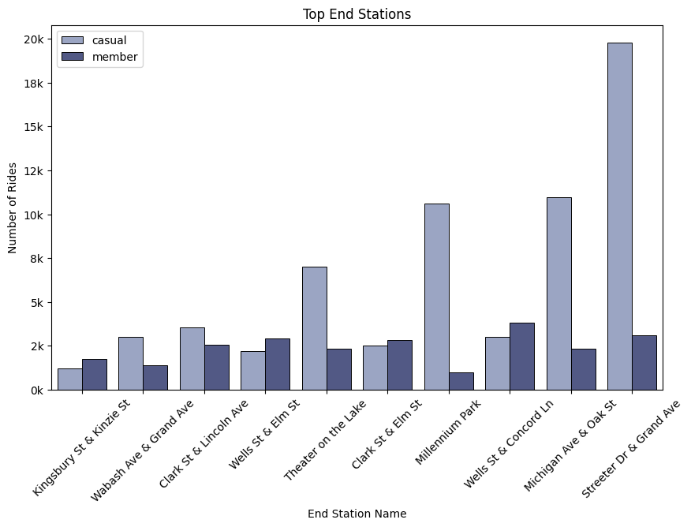

```python
plt.figure(figsize = (10, 6))
sns.countplot(x = 'end_station_name',
              hue = 'member_casual',
              data = top_stations,
              palette = {'member': member_color, 'casual': casual_color},
              order = top_end_stations,
              linewidth = 0.7,
              edgecolor = 'black')
plt.title('Top End Stations')
plt.xlabel('End Station Name')
plt.ylabel('Number of Rides')
plt.xticks(rotation = 45)

plt.gca().yaxis.set_major_formatter(FuncFormatter(lambda x, _: '{:,.0f}k'.format(x/1000)))

plt.legend()
plt.show()
```

### Top Stations - Members

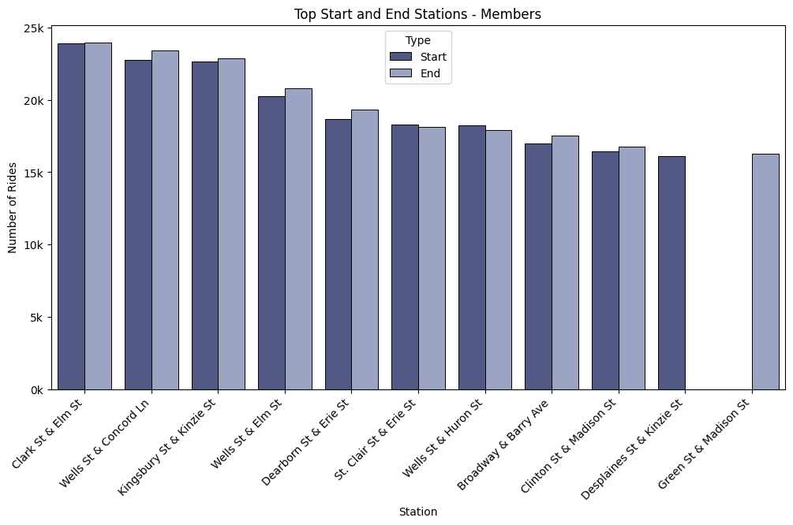

```python
plt.figure(figsize = (12, 6))
sns.barplot(x = 'index', y = 'Number of Rides',
            hue = 'Type',
            data = top_stations_members,
            palette = [member_color, casual_color],
            linewidth = 0.7,
            edgecolor = 'black')
plt.xlabel('Station')
plt.ylabel('Number of Rides')
plt.title('Top Start and End Stations - Members')
plt.xticks(rotation = 45, ha = 'right')

plt.gca().yaxis.set_major_formatter(FuncFormatter(lambda x, _: '{:,.0f}k'.format(x/1000)))

plt.show()
```

### Top Stations - Casual Riders

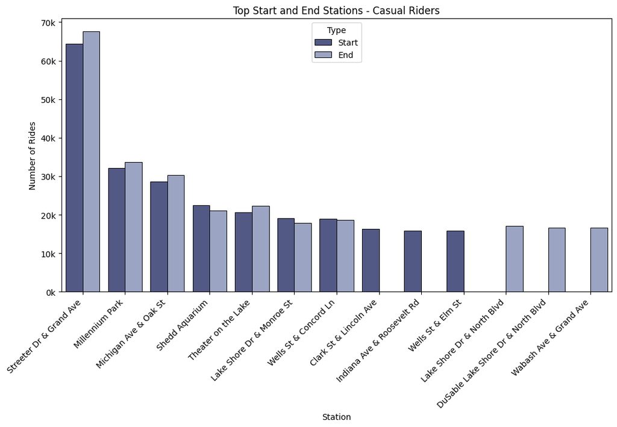

```python
plt.figure(figsize = (12, 6))
sns.barplot(x = 'index', y = 'Number of Rides', hue = 'Type',
            data = top_stations_casual,
            palette = [member_color, casual_color],
            linewidth = 0.7,
            edgecolor = 'black')
plt.xlabel('Station')
plt.ylabel('Number of Rides')
plt.title('Top Start and End Stations - Casual Riders')
plt.xticks(rotation = 45, ha = 'right')

plt.gca().yaxis.set_major_formatter(FuncFormatter(lambda x, _: '{:,.0f}k'.format(x/1000)))

plt.show()
```

## Weekly Ridership

[figure not shown]

```python
plt.figure(figsize = (10, 6))
sns.countplot(x = 'day_of_week',
              hue= 'member_casual',
              data = df, palette = {'member': member_color, 'casual': casual_color},
              order = days,
              linewidth = 0.7,
              edgecolor = 'black')
plt.title('Average Daily Ridership')
plt.xlabel('Day of Week')
plt.ylabel('Number of Rides')
plt.xticks(rotation = 45)
plt.legend()
plt.gca().yaxis.set_major_formatter(FuncFormatter(lambda x, _: '{:,.0f}k'.format(x/1000)))
plt.show()
```

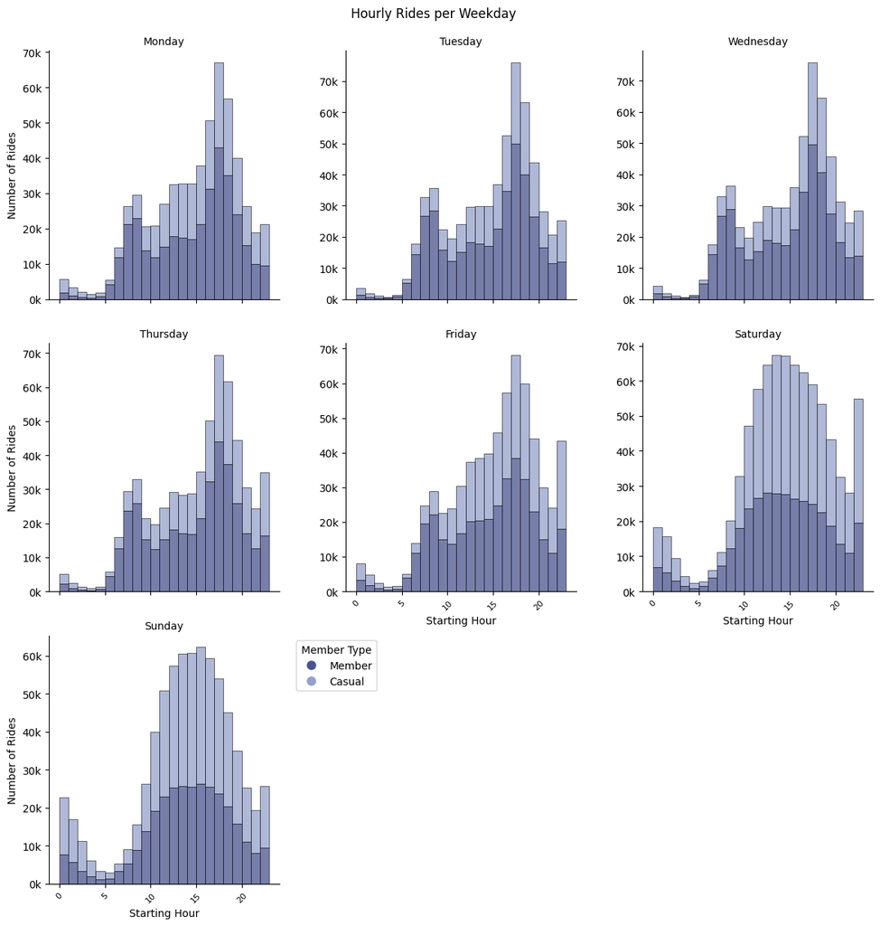

```python
g = sns.FacetGrid(df, col = 'day_of_week', col_wrap = 3, height = 4, sharey = False,
                  col_order = days)
g.map_dataframe(sns.histplot, x='start_hour', hue='member_casual',
                palette={'member': member_color, 'casual': casual_color},
                multiple = 'stack',
                binwidth = 1,
                edgecolor = 'black',
                linewidth = 0.4,
                hue_order = ['casual', 'member'])

g.set_axis_labels('Starting Hour', 'Number of Rides')
g.set_titles(col_template = "{col_name}")
g.fig.suptitle('Hourly Rides per Weekday', y = 1.02)

def format_thousands(value, _):
    return '{:.0f}k'.format(value / 1000)

for ax in g.axes.flat:
    ax.yaxis.set_major_formatter(FuncFormatter(format_thousands))

for ax in g.axes.flat:
    ax.tick_params(axis = 'x', labelrotation = 45, labelsize = 8)

handles = [plt.Line2D([0], [0], marker = 'o', color = 'w', markerfacecolor = member_color, markersize = 10),
           plt.Line2D([0], [0], marker = 'o', color = 'w', markerfacecolor = casual_color, markersize = 10)]
labels = ['Member', 'Casual']

plt.legend(handles, labels, title = 'Member Type', bbox_to_anchor = (1.05, 1), loc = 'upper left')

plt.show()
```

[figure not shown]

```python
grouped_df = df.groupby(['day_of_week', 'member_casual']).agg(avg_duration = ('ride_length_m', 'mean')).reset_index()

plt.figure(figsize = (10, 6))
sns.barplot(x = 'day_of_week', y = 'avg_duration',
            hue = 'member_casual',
            data = grouped_df,
            palette = {'member': member_color, 'casual': casual_color},
            order = days,
            edgecolor = 'black',
            linewidth = 0.4)
plt.xlabel('Day of Week')
plt.ylabel('Average Trip Duration (minutes)')
plt.title('Average Daily Trip Duration')
plt.legend(title = 'Member Type')
plt.show()
```

```python
average_ride_length_member = member['ride_length_m'].mean()
average_ride_length_casual = casual['ride_length_m'].mean()

f"Average Ride Length for Members: {round(average_ride_length_member, 2)} minutes.\
 Average Ride Length for Casual Riders: {round(average_ride_length_casual, 2)} minutes."
```

```
'Average Ride Length for Members: 13.18 minutes. Average Ride Length for Casual Riders: 32.51 minutes.'
```

## Monthly Ridership

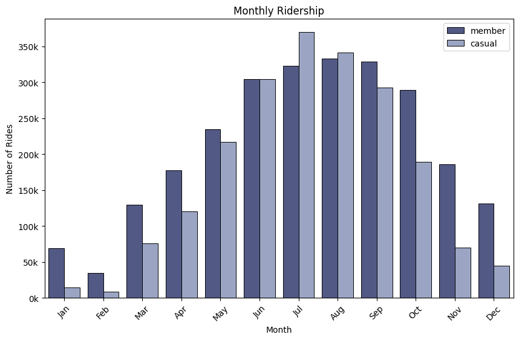

```python
plt.figure(figsize = (10, 6))
sns.countplot(x = 'month',
              hue= 'member_casual',
              data = df,
              palette = {'member': member_color, 'casual': casual_color},
              order = range(1,13),
              linewidth = 0.7,
              edgecolor = 'black')
plt.title('Monthly Ridership')
plt.xlabel('Month')
plt.ylabel('Number of Rides')
plt.xticks(rotation = 45)

plt.xticks(range(0, 12), ['Jan', 'Feb', 'Mar', 'Apr', 'May', 'Jun', 'Jul', 'Aug', 'Sep', 'Oct', 'Nov', 'Dec'])
plt.gca().yaxis.set_major_formatter(FuncFormatter(lambda x, _: '{:,.0f}k'.format(x/1000)))

plt.legend()
plt.show()
```

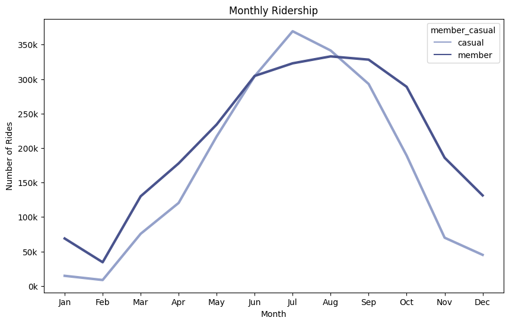

```python
plt.figure(figsize = (10, 6))
sns.lineplot(x = 'month', y = 'ride_count',
             hue = 'member_casual',
             data = ride_counts_month,
             palette = [casual_color, member_color],
             linewidth = 3)
plt.xlabel('Month')
plt.ylabel('Number of Rides')
plt.title('Monthly Ridership')
plt.xticks(range(1, 13), ['Jan', 'Feb', 'Mar', 'Apr', 'May', 'Jun', 'Jul', 'Aug', 'Sep', 'Oct', 'Nov', 'Dec'])

plt.gca().yaxis.set_major_formatter(FuncFormatter(lambda x, _: '{:,.0f}k'.format(x/1000)))

plt.show()
```

## Quarterly Ridership

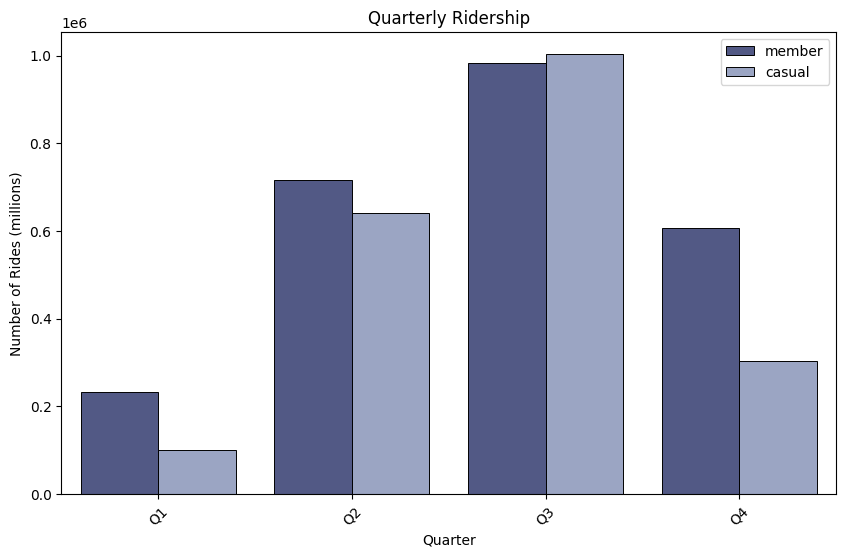

```python
plt.figure(figsize = (10, 6))
sns.countplot(
    x = 'quarters',
    hue = 'member_casual',
    data = df,
    palette = {'member': member_color, 'casual': casual_color},
    order = range(1, 5),
    linewidth = 0.7,
    edgecolor = 'black'
)

plt.title('Quarterly Ridership')
plt.xlabel('Quarter')
plt.ylabel('Number of Rides (millions)')
plt.xticks(rotation = 45)

quarters = ['Q1', 'Q2', 'Q3', 'Q4']
plt.xticks(ticks = range(4), labels = quarters)

plt.legend()
plt.show()
```

# Conclusion

## Key Points

##### Members

- **Trips made:** 55.4% of 2021 trips
- **Favorite Station:** Clark St & Elm St
- **Peak Time:** 17:00
- **Rush Hour:** Morning and Evening
- **Peak Season:** Summer
- **Low Season:** Winter
- **Ride Length:** Stable throughout the year

##### Casual Riders

- **Trips made:** 44.6% of 2021 trips
- **Favorite Station:** Streeter Dr & Grand Ave
- **Peak Time:** 17:00
- **Rush Hour:** Evening
- **Peak Season:** Summer
- **Low Season:** Winter (more drastic downturn than members)
- **Ride Length:** Peaks during weekends
- **Casual riders out-ride members during the peak season**

## Recommendation

1. Tap into different types of riders

Commuter Membership (targets existing members and potential members)

- Priority usage morning and evening rush hour.

Recreational Membership (targets current casual riders)

- Priority usage during weekends.
- Introduce special rates or promotions for weekend rides.
- Allow users to bring friends on rides at reduced rates (since use is mostly recreational, it could be likely that users typically ride with others)
1. Tap into seasonality in ridership
- Introduce incentives (ex. discounted membership) for users who sign up to be members during the low season.